# A novel study of the Buzzard Simulation

## R Markdown

```r
rm(list=ls())
file.path = file.path = "https://raw.githubusercontent.com/pefreeman/36-290/master/PROJECT_DATASETS/BUZZARD/Buzzard_DC1.Rdata"
load(url(file.path))
rm(file.path)
objects()
```

```
## [1] "df"
```

## Introduction and Data

‘’’ The BUZZARD data set were produced from a simulation with Large Synoptic Survey Telescope (LSST) Data Challenge 1 (DC1), BUZZARD implies that data comes from a simulation so the models we create can be finetuned when actual data is presented. A portion of our predictor space includes variables denoted as mag.u, mag.i, mag.r, mag.z, mag.y, and mag.g. These are essentially a way of measuring the “brightness” of galaxies. These predictors are valuable because in this study we are attempting to analyze redshift, a way of using visual cues to approximate how far a galaxy is. Essentially based on the kinds of redhsift we see coming from a galaxy, we can determine how far away it is based on the wavelength. We will be using both redshift and the mag’s to model mass of a galaxy. We will first convert the mag predictors to colors however, We will be attempting to relate photoemetry to mass first and then in a different part of the study, we will predict redshift from photometry alone and then use those predictions of redhsift and our original photoemtry used to make those predictions to predict mass. Some high level questions we can answer are: How effectively can we predict redshift from photoemtry? From the predicted redshift and photemtry can we predict galaxy mass?

Our data contains 111,171 galaxie with 14 variables. We will disregard the error terms and proceed with EDA with our mag converted to colors and an r band along with the rest of our predictor space. ‘’’

## Exploratory Data Analysis

```r
dfTask1=data.frame(df[1:6],df[,13])
dfTask1Col=data.frame(df[1:6][-1] - df[1:6][-ncol(df[1:6])], df[,13])
dfTask2=data.frame(df[1:6][-1] - df[1:6][-ncol(df[1:6])],df[3],df[13:14])
library(tidyverse)
```

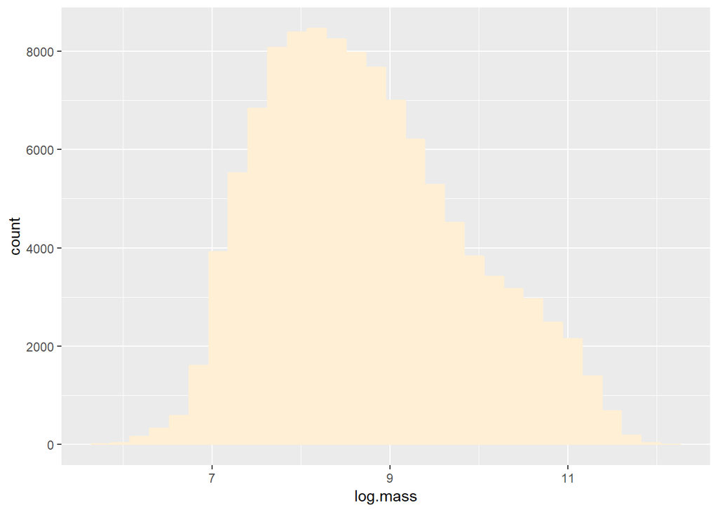

```
First, let's look at the general distribution of the log.mass galaxies
```

```r
ggplot(data=df,aes(x=log.mass))+geom_histogram(color="papayawhip",fill="papayawhip")
```

```r
library(GGally)
```

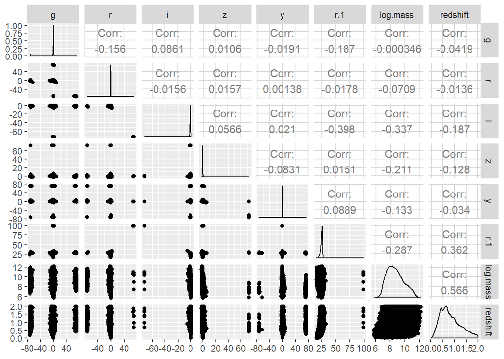

[output not shown]

```r
ggpairs(dfTask2,progress=FALSE)
```

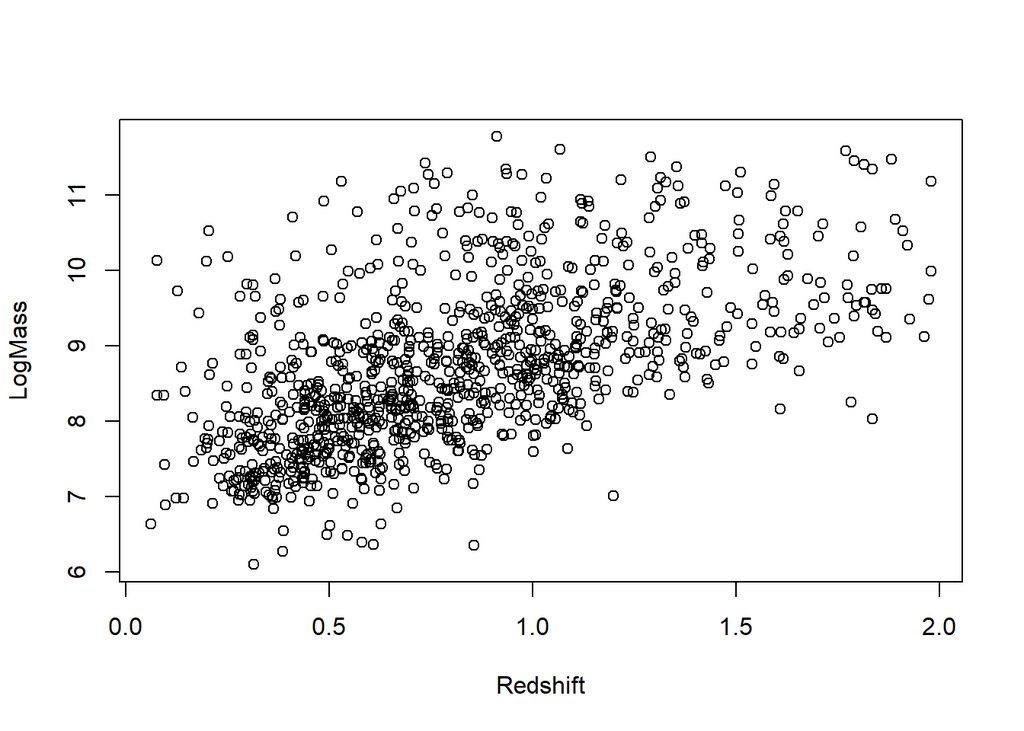

```
There is certainly a correlation between our redshift and log.mass. Let's see how well we can predict log.mass with a simple linear model. Later in our analysis, we will use predicted redshift, but for now let us use the given redshift sample.
```

```r
set.seed(103)
ind=sample(1:111171, 1000, replace=FALSE)

plot(dfTask2[,8][ind],dfTask2[,7][ind], xlab="Redshift", ylab="LogMass")
```

```r
tempFrame=data.frame(dfTask2[,8][ind],dfTask2[,7][ind])
 colnames(tempFrame) <- c("redshift", "log.mass")
linearMod <- lm(log.mass ~ redshift, data=tempFrame)
set.seed(290)
testIndex = sample(1:111171, 1000, replace=FALSE)
pri = data.frame(dfTask2[,8][testIndex])
colnames(pri) <- c("redshift")
pred = predict(linearMod, newdata=pri)
mse = mean((pred-dfTask2[,7][testIndex]))^2
mse
```

```
## [1] 0.0007887128
```

[output not shown]

```r
onlyPred = data.frame(dfTask2[,1:6],dfTask2[,8])
colnames(onlyPred) <- c("col.u.g","col.g.r","col.r.i","col.i.z","col.z.y","r.band", "redshift")
cor(onlyPred)
```

```
##              col.u.g     col.g.r     col.r.i     col.i.z     col.z.y
## col.u.g   1.00000000 -0.15573216  0.08613305  0.01058620 -0.01905953
## col.g.r  -0.15573216  1.00000000 -0.01556467  0.01570172  0.00138113
## col.r.i   0.08613305 -0.01556467  1.00000000  0.05663049  0.02100961
## col.i.z   0.01058620  0.01570172  0.05663049  1.00000000 -0.08305187
## col.z.y  -0.01905953  0.00138113  0.02100961 -0.08305187  1.00000000
## r.band   -0.18731772 -0.01775553 -0.39810295  0.01508493  0.08892831
## redshift -0.04188639 -0.01360255 -0.18732249 -0.12842290 -0.03403849
##               r.band    redshift
## col.u.g  -0.18731772 -0.04188639
## col.g.r  -0.01775553 -0.01360255
## col.r.i  -0.39810295 -0.18732249
## col.i.z   0.01508493 -0.12842290
## col.z.y   0.08892831 -0.03403849
## r.band    1.00000000  0.36210994
## redshift  0.36210994  1.00000000
```

```
There are not any correlations that stand out from our table, however this simply checks for linear relationships. Let's see visually how our 2 highest correlations look on a plot. mag.r and redshift as well as col.r-i and mag.r.
```

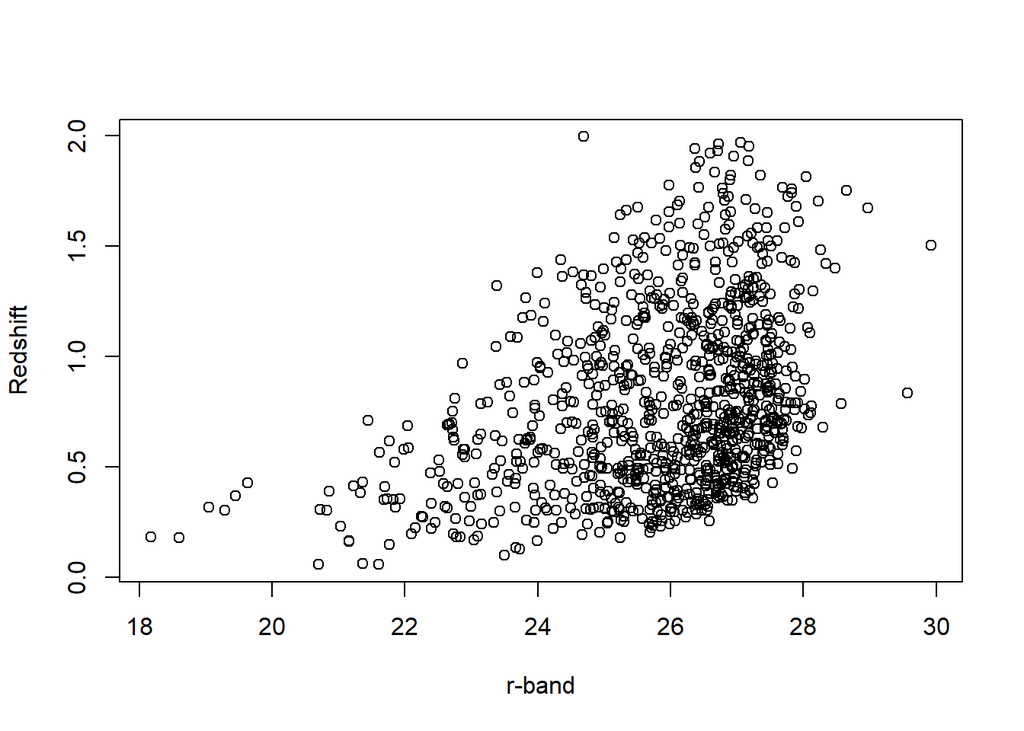

```r
set.seed(180)
ind=sample(1:111171, 1000, replace=FALSE)

plot(onlyPred[,6][ind],onlyPred[,7][ind], xlab="r-band", ylab="Redshift")
```

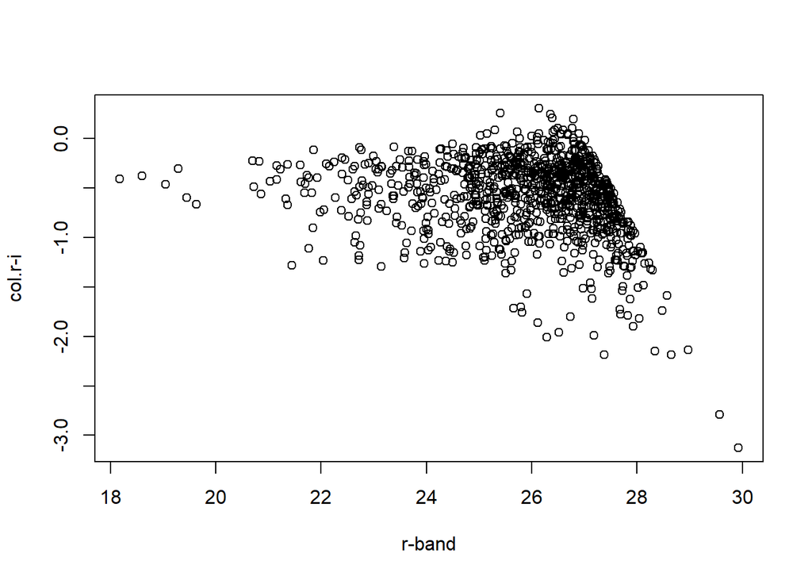

```
Obviously there is not a linear relationship here, but there is some kind of noticeable relationship with the both pairs of plots. Let's employ PCA to really weed out the important variables in our predictor space.
```

```r
plot(onlyPred[,6][ind],onlyPred[,3][ind], xlab="r-band", ylab="col.r-i")
```

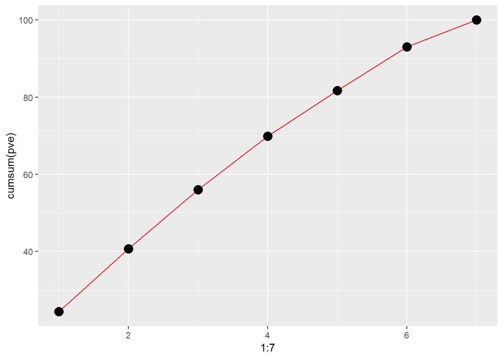

[output not shown]

```r
library(tidyverse)
v=prcomp(onlyPred,scale.=TRUE)
pve =100*v$sdev ^2/sum(v$sdev ^2)
g=data.frame((1:7),pve,cumsum(pve))
ggplot(g, mapping=aes(x=1:7,y=cumsum(pve)))+geom_line(color="red")+geom_point(size=4)
```

## Modeling

```
We'll kick things off with Ridge regression. First, let's set up the predictor/response split we will use from now on.
```

```r
library(glmnet)
library(Matrix)
library(dbplyr)
library(dplyr)
set.seed(47)
frac = 0.8
len = nrow(onlyPred)
ind = sample(len, frac * len)
pred.train = onlyPred[ind,1:6]
resp.train = onlyPred[ind,7]
RedShiftTrain = data.frame(pred.train,resp.train)
pred.test = onlyPred[-ind,1:6]
resp.test = onlyPred[-ind,7]
x=model.matrix(resp.train~.,pred.train)[,-1]
xTest=model.matrix(resp.test~.,pred.test)[,-1]
y=resp.train
grid=10^seq(10,-2,length=100)
ridge.mod=glmnet(x,y,alpha=0,lambda=grid)
dim(coef(ridge.mod))
```

```
## [1]   7 100
```

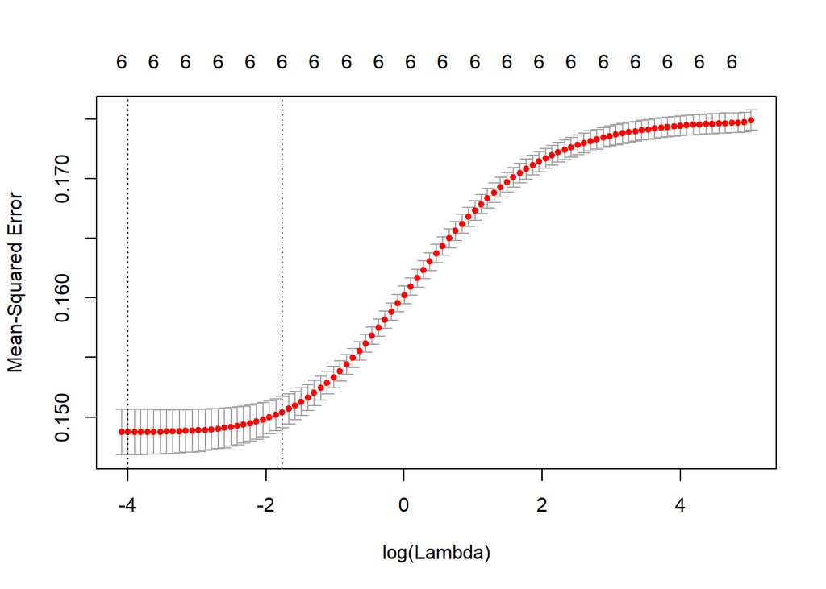

```r
set.seed(1)
cv.out=cv.glmnet(x,y,alpha=0)
plot(cv.out)
```

```r
bestlam =cv.out$lambda.min
ridge.pred=predict(ridge.mod ,s=bestlam ,newx=xTest)
ridgeMean=mean((ridge.pred-resp.test)^2)
ridgeMean
```

```
## [1] 0.1464227
```

```r
mseFrameRedShift = data.frame("RidgeMean", ridgeMean)
```

```
A Ridge model yields a favorable mse. 0.146 is defintely a good place to start predicting redshift from. However, let's just save that mse into a mse dataFrame and continue with other modeling techniques. Perhaps we can do even better.
```

```r
library(tree)
library(xgboost)
library(tidyverse)
library(dplyr)
library(FNN)
tree.star=tree(resp.train~.,data=RedShiftTrain)
summary(tree.star)
```

```
##
## Regression tree:
## tree(formula = resp.train ~ ., data = RedShiftTrain)
## Variables actually used in tree construction:
## [1] "col.i.z" "col.z.y" "col.g.r" "col.r.i" "r.band"
## Number of terminal nodes:  10
## Residual mean deviance:  0.08702 = 7738 / 88930
## Distribution of residuals:
##     Min.  1st Qu.   Median     Mean  3rd Qu.     Max.
## -1.14500 -0.16630 -0.03434  0.00000  0.10600  1.60800
```

```r
treePred=predict(tree.star,newdata=pred.test)
mseTree=mean((treePred-resp.test)^2)

mat=xgb.DMatrix(data=as.matrix(pred.train),label=resp.train)
set.seed(103)
out=xgb.cv(params=list(objective="reg:linear"),data=mat,nfold=10,nround=20,verbose=0)
numTrees=which.min(out$evaluation_log$test_rmse_mean)
fit=xgboost(mat,nrounds=numTrees, params=list(objective="reg:linear"))
pred=predict(fit,newdata=xgb.DMatrix(data=as.matrix(pred.test)))
mseBoost=mean((pred-resp.test)^2)
mseBoost
```

```
## [1] 0.0554249
```

```r
mseFrame=array()
arr=seq(1,3)
ii=1
for(ii in arr){
  v=knn.reg(pred.train, y= resp.train, k = ii, algorithm="brute")
  mse2=mean((v$pred-resp.train)^2)
  mseFrame[ii]=mse2


}
out1=knn.reg(pred.test, y= resp.test, k = which.min(mseFrame), algorithm="brute")
dfT=data.frame(mseFrame,arr)
mcrKNeares=mean((out1$pred-resp.test)^2)
mcrKNeares
```

```
## [1] 0.07237175
```

[output not shown]

```r
library(e1071)
svmmodel <- svm(resp.train ~., RedShiftTrain)
predictedY <- predict(svmmodel, pred.test)
svmMse = mean((predictedY-resp.test)^2)
```

[output not shown]

[output not shown]

```r
predRedShift=predict(fit,newdata=xgb.DMatrix(data=as.matrix(onlyPred[,1:6])))
MassPred = data.frame(onlyPred[,1:6], predRedShift, df[,13])
set.seed(47)
frac = 0.8
len = nrow(MassPred)
ind = sample(len, frac * len)
pred.trainMass = MassPred[ind,1:7]
resp.trainMass = MassPred[ind,8]
RedShiftTrain = data.frame(pred.trainMass,resp.trainMass)
pred.testMass = MassPred[-ind,1:7]
resp.testMass = MassPred[-ind,8]
xFin=model.matrix(resp.trainMass~.,pred.trainMass)[,-1]
xTestFin=model.matrix(resp.testMass~.,pred.testMass)[,-1]
y=resp.trainMass
grid=10^seq(10,-2,length=100)
ridge.mod=glmnet(xFin,y,alpha=0,lambda=grid)
dim(coef(ridge.mod))
```

```
## [1]   8 100
```

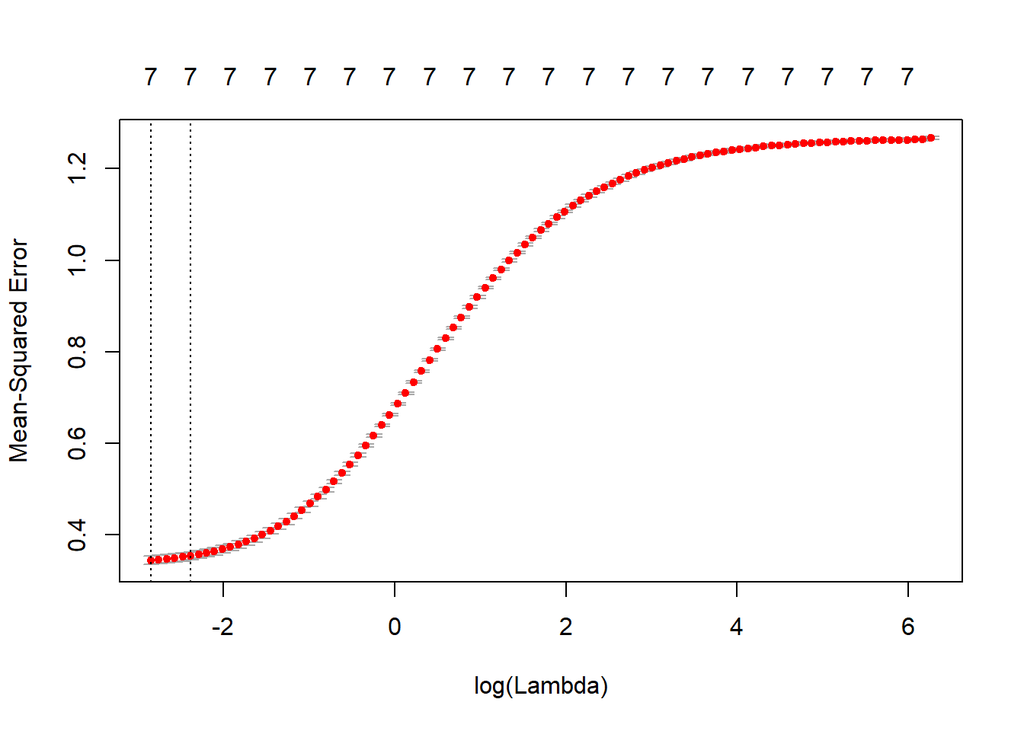

```r
set.seed(1)
cv.out=cv.glmnet(xFin,y,alpha=0)
plot(cv.out)
```

```r
bestlam =cv.out$lambda.min
ridge.pred=predict(ridge.mod ,s=bestlam ,newx=xTestFin)
ridgeMean=mean((ridge.pred-resp.testMass)^2)
ridgeMean
```

```
## [1] 0.356788
```

```r
mseFrameRedShift = data.frame("RidgeMean", ridgeMean)
```

[output not shown]

```r
library(randomForest)
colnames(MassPred) <- c("col.u.g","col.g.r","col.r.i","col.i.z","col.z.y","r.band", "redshift","log.mass")
set.seed(47)
frac = 0.1
len = nrow(MassPred)
ind = sample(len, frac * len)
pred.trainMassSmall = MassPred[ind,1:7]
resp.trainMassSmall = MassPred[ind,8]
smallerFrame=data.frame(pred.trainMassSmall,resp.trainMassSmall)
rf1 <- randomForest(resp.trainMassSmall~.,
                data=smallerFrame)
rf1$importance
```

```
##          IncNodePurity
## col.u.g       405.5208
## col.g.r      1154.1899
## col.r.i      2690.8880
## col.i.z      3290.7928
## col.z.y      1930.5806
## r.band       2297.6263
## redshift     2131.4234
```

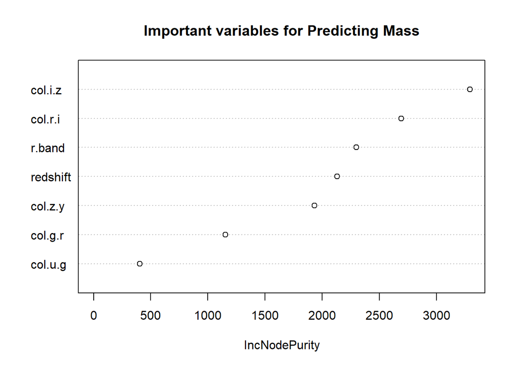

```
It seems that col.u-g is least important for predicting mass and col.i-z is most important. However since all of them have purity scores above 400, I not drop any from the model. Let's continue with trees, boosting, and k-nearest neighbors.
```

```r
varImpPlot(rf1,main="Important variables for Predicting Mass")
```

```r
library(tree)
library(xgboost)
library(tidyverse)
library(dplyr)
library(FNN)
tree.star=tree(resp.trainMass~.,data=pred.trainMass)
summary(tree.star)
```

```
##
## Regression tree:
## tree(formula = resp.trainMass ~ ., data = pred.trainMass)
## Variables actually used in tree construction:
## [1] "col.i.z"      "col.z.y"      "col.r.i"      "r.band"
## [5] "predRedShift"
## Number of terminal nodes:  12
## Residual mean deviance:  0.4475 = 39790 / 88920
## Distribution of residuals:
##     Min.  1st Qu.   Median     Mean  3rd Qu.     Max.
## -3.05400 -0.42650 -0.02444  0.00000  0.40650  3.42900
```

```r
treePred=predict(tree.star,newdata=pred.testMass)
mseTree=mean((treePred-resp.testMass)^2)

mat=xgb.DMatrix(data=as.matrix(pred.trainMass),label=resp.trainMass)
set.seed(103)
out=xgb.cv(params=list(objective="reg:linear"),data=mat,nfold=10,nround=20,verbose=0)
numTrees=which.min(out$evaluation_log$test_rmse_mean)
fit=xgboost(mat,nrounds=numTrees, params=list(objective="reg:linear"))
pred=predict(fit,newdata=xgb.DMatrix(data=as.matrix(pred.testMass)))
mseBoost=mean((pred-resp.testMass)^2)
mseBoost
```

```
## [1] 0.1900889
```

```r
mseFrame=array()
arr=seq(1,3)
ii=1
for(ii in arr){
  v=knn.reg(pred.trainMass, y= resp.trainMass, k = ii, algorithm="brute")
  mse2=mean((v$pred-resp.trainMass)^2)
  mseFrame[ii]=mse2


}
out2=knn.reg(pred.testMass, y= resp.testMass, k = which.min(mseFrame), algorithm="brute")
mcrKNeares=mean((out2$pred-resp.testMass)^2)
mcrKNeares
```

```
## [1] 0.2486489
```

[output not shown]

```r
library(tree)
library(xgboost)
library(tidyverse)
library(dplyr)
library(FNN)
tree.star=tree(resp.trainMass~.,data=pred.trainMass[,-1])
summary(tree.star)
```

```
##
## Regression tree:
## tree(formula = resp.trainMass ~ ., data = pred.trainMass[, -1])
## Variables actually used in tree construction:
## [1] "col.i.z"      "col.z.y"      "col.r.i"      "r.band"
## [5] "predRedShift"
## Number of terminal nodes:  12
## Residual mean deviance:  0.4475 = 39790 / 88920
## Distribution of residuals:
##     Min.  1st Qu.   Median     Mean  3rd Qu.     Max.
## -3.05400 -0.42650 -0.02444  0.00000  0.40650  3.42900
```

```r
treePred=predict(tree.star,newdata=pred.testMass[,-1])
mseTree=mean((treePred-resp.testMass)^2)

mat=xgb.DMatrix(data=as.matrix(pred.trainMass[,-1]),label=resp.trainMass)
set.seed(103)
out=xgb.cv(params=list(objective="reg:linear"),data=mat,nfold=10,nround=20,verbose=0)
numTrees=which.min(out$evaluation_log$test_rmse_mean)
fit=xgboost(mat,nrounds=numTrees, params=list(objective="reg:linear"))
pred=predict(fit,newdata=xgb.DMatrix(data=as.matrix(pred.testMass[,-1])))
mseBoost=mean((pred-resp.testMass)^2)
mseBoost
```

```
## [1] 0.1909936
```

```r
mseFrame=array()
arr=seq(1,3)
ii=1
for(ii in arr){
  v=knn.reg(pred.trainMass[,-1], y= resp.trainMass, k = ii, algorithm="brute")
  mse2=mean((v$pred-resp.trainMass)^2)
  mseFrame[ii]=mse2


}
out2=knn.reg(pred.testMass[,-1], y= resp.testMass, k = which.min(mseFrame), algorithm="brute")
mcrKNeares=mean((out2$pred-resp.testMass)^2)
mcrKNeares
```

```
## [1] 0.2354284
```

[output not shown]

[figure not shown]

```r
library(tidyverse)
library(dplyr)
ind = sample(length(pred), (0.05 * length(pred)))
plot(pred[ind],resp.test[ind],xlab="Boosting Predictions",ylab="Actual log.mass")
```

## Conclusion

```
The plot displays a relative strong amount of scatter. We have reason to believe the boosting model for predicting mass from colors and mag.r along with a predicted redshift will be a good model to tune for real galaxy data. Boosting also was effective in predicting the redshift predictor space we would use in the model. The mse values for KNN, Boosting, Ridge, and Trees were all low when it came to predicting redshift, but did not keep their strength when predicting mass. The Buzzard simulation provided us with the task of modeling redshift from colors and from there using all of the prior to model mass and in this study we came up with an effective model.
```